# 12 — Probabilistic models 2

Machine Learning (MPA-MLR)

Roman Jakubíček

Department of Biomedical Engineering · FEEC, Brno University of Technology

2025

## Outline

0 · Why probability at all

Loss functions, regularization and generative models are probability in disguise.

1 · Naive Bayes classifier

One $d$-dimensional density replaced by $K \times d$ one-dimensional ones.

2 · Gaussian mixture model

Several Gaussians instead of one — and the EM algorithm that fits them.

3 · Logistic regression

A sigmoid, a Bernoulli likelihood, and the cross-entropy we already know.

## Probabilistic models — the two lectures

**Previous lecture** — Probabilistic models 1

- Probability introduction + Bayes’ rule
- Probabilistic models — parameter estimation:
  - Maximum likelihood (MLE)
  - Maximum a-posteriori (MAP)
  - Bayesian inference

**This lecture** — Probabilistic models 2

- Probabilistic models — example applications:
  - Naive Bayes classifier
  - Gaussian mixture model — EM algorithm
  - Logistic regression

Last time we asked *what are the parameters of one distribution?* Today we ask *what can we build out of such distributions?*

The original slide writes „Maximum a-posteriory“; the correct spelling is *a-posteriori*.

## Why probability theory is fundamental — losses and regularization

A lot of things in machine learning are **derived** using probability.

- **Loss functions = assumptions about noise, plus MLE.** The L2 loss from the sixth lecture is the maximum likelihood solution under Gaussian noise; cross-entropy is the maximum likelihood solution under a Bernoulli (or categorical) likelihood. We derive both today.
- **Regularization = a prior.** Weight decay from the sixth lecture is exactly a zero-mean Gaussian prior on the weights inside a MAP estimate; DropOut switches neurons off with a Bernoulli variable.

$$\underbrace{\arg\min_{\mathbf w}\ \sum_i L(y_i, f_{\mathbf w}(\mathbf x_i))
+ \lambda \|\mathbf w\|^2}_{\text{what we have been writing since the fourth lecture}}
\quad = \quad
\underbrace{\arg\max_{\mathbf w}\ p(D \mid \mathbf w)\, p(\mathbf w)}_{\text{MAP from the previous lecture}}$$

## Why probability theory is fundamental — optimization and generative models

- **Stochastic gradient descent = Monte Carlo estimation.** The mini-batch gradient from the sixth lecture is an *unbiased* estimate of the full-data gradient — that is exactly what a Monte Carlo estimate is.
- **Generative models = modelling the data distribution**, compared with a KL divergence (GANs, VAEs, diffusion models, normalizing flows, autoregressive models). The generative-versus-discriminative table from the previous lecture is the same distinction.
- **Transformers and language models = conditional probabilities.** The transformer decoder from the tenth lecture predicts the next token — that is $p(x_t \mid x_1, \dots, x_{t-1})$, nothing else.

> *Probability theory is the theoretical engine behind innovation in machine learning — essential for discovering new models, even if it is hidden during the practical implementation.*

## Example — regression: the model and the likelihood

**Model** (prediction plus Gaussian noise):
$$y_i = f_{\boldsymbol\theta}(x_i) + \varepsilon_i, \qquad
\varepsilon_i \sim \mathcal{N}(0, \sigma^2)$$

**Likelihood of one sample** — the noise distribution shifted to the prediction:
$$p(y_i \mid x_i, \boldsymbol\theta) =
\frac{1}{\sqrt{2\pi\sigma^2}}
\exp\!\left( -\frac{\big(y_i - f_{\boldsymbol\theta}(x_i)\big)^2}{2\sigma^2} \right)$$

**Likelihood of the whole i.i.d. data set** $D = \{(x_i, y_i)\}_{i=1}^{n}$:
$$L(\boldsymbol\theta) = p(D \mid \boldsymbol\theta)
= \prod_{i=1}^{n} p(y_i \mid x_i, \boldsymbol\theta)$$

The original slide jumps straight from one sample to the sum; the product step is added here. The original also typesets the normal distribution with a Greek capital Ν — it is $\mathcal{N}$, as in the previous lecture.

## Example — regression: from the negative log-likelihood to the L2 loss

**Negative log-likelihood** — the product becomes a sum:
$$-\log L(\boldsymbol\theta) = \sum_{i=1}^{n}
\frac{\big(y_i - f_{\boldsymbol\theta}(x_i)\big)^2}{2\sigma^2}
+ \underbrace{n \log \sqrt{2\pi\sigma^2}}_{\text{const}}$$

**Minimization** — constants and positive factors do not move the minimum:
$$\boldsymbol\theta^{*} = \arg\min_{\boldsymbol\theta}
\sum_{i=1}^{n} \big(y_i - f_{\boldsymbol\theta}(x_i)\big)^{2}$$

This is the **L2 loss from the sixth lecture**. It is not a definition — it is what MLE gives us once we assume Gaussian noise.

## The same minimum — computed

[figure not shown]

40 samples of $y_i = \theta x_i + \varepsilon_i$ with $\varepsilon_i \sim \mathcal{N}(0, 1.5^2)$. The two curves on the right differ only by an additive constant and a positive factor, so they are minimized at the same $\hat\theta = 1.024$ — which is also the least-squares solution $\hat\theta = \sum_i x_i y_i / \sum_i x_i^2$.

## 1 · Naive Bayes classifiers

> How do we turn distributions into a classifier — and what do we gain by pretending the features are independent?

## Bayesian classifiers — the posterior of a class

Given measured data $\mathbf{x}$ and a class $y \in \{y_1, \dots, y_K\}$, we want the **posterior probability of the class** $p(y_k \mid \mathbf{x})$. We apply Bayes’ rule:

$$\underbrace{p(y_k \mid \mathbf{x})}_{\textbf{posterior}} =
\frac{\overbrace{p(\mathbf{x} \mid y_k)}^{\textbf{likelihood}}\ \overbrace{p(y_k)}^{\textbf{prior}}}
{\underbrace{p(\mathbf{x})}_{\textbf{evidence}}}
= \frac{p(x_1, x_2, \dots, x_d \mid y_k)\, p(y_k)}
{\sum_{j=1}^{K} p(x_1, x_2, \dots, x_d \mid y_j)\, p(y_j)}$$

- $p(\mathbf{x} \mid y_k)$ — a **conditional density**, estimated from the training samples of class $k$.
- $p(y_k)$ — estimated from the data as the **frequency** of class $k$.
- $p(\mathbf{x})$ — a **sum over $K$ discrete classes**, so it can always be computed. It only normalizes the posterior to 1.

The original writes the summation index in the denominator as $k$, the same letter that is fixed in the numerator; the slide on the EM algorithm writes it correctly as $\sum_{j=1}^{K}$ and that form is used here.

## Bayesian classifiers — the decision rule and its problem

We are most interested in the **most probable class**. The denominator does not depend on $k$, so it drops out:
$$y_k^{*} = \arg\max_{y_k}\ p(\mathbf{x} \mid y_k)\, p(y_k)$$

From the training set $D$ we take only the samples of class $k$ and fit the parameters of $p_{\boldsymbol\theta}(x_1, \dots, x_d \mid y_k)$, e.g. by ML estimation.

**However** — this distribution is $d$-dimensional. A full Gaussian needs $d + \frac{d(d+1)}{2}$ parameters **per class**: 65 numbers for $d = 10$, 5150 for $d = 100$.

[figure not shown]

A **simulation** — the seminar data has only $d = 2$, so it cannot show what happens in eight dimensions. Averaged over 40 repetitions.

## Naive Bayes — the conditional independence assumption

Assume the features are **mutually independent, conditional on the class** $y_k$:

$$y_k^{*} = \arg\max_{y_k}\ p(x_1, \dots, x_d \mid y_k)\, p(y_k)
= \arg\max_{y_k}\ p(y_k) \prod_{i=1}^{d} p_{\boldsymbol\theta}(x_i \mid y_k)$$

One $d$-dimensional density is replaced by a **product of $d$ one-dimensional densities** — and each of them may be of a different type (normal for a continuous feature, Bernoulli for a binary one, categorical for a discrete one).

Independence *conditional on the class* is much weaker than plain independence. In the seminar data set tumour size and HPV status have correlation $0.16$ overall, but only $0.03$ / $0.05$ / $0.09$ **inside** the three classes — so the naive assumption is nearly satisfied here, even though the features look dependent when the classes are pooled.

## Naive Bayes — the K × d distributions

The task is to find the distributions $p(x_i \mid y_k)$, each described by a parameter vector $\boldsymbol\theta_{i,k}$ for the $i$-th feature conditioned on the $k$-th class — that is **$K \times d$ distributions**.

For the $i$-th feature we have observed $n$ values $[f_1, f_2, \dots, f_n]$; the parameters $\boldsymbol\theta_{i,k}$ are estimated only from the subset $\mathbf{f}_{i,k} = \mathbf{f}(x_i \mid y_k)$ belonging to class $k$, because $p(x_i \mid y_k)$ is conditioned on $y_k$:
$$\boldsymbol\theta^{*}_{\mathrm{MAP}} = \arg\max_{\boldsymbol\theta_{i,k}}
p(\boldsymbol\theta_{i,k} \mid \mathbf{f}_{i,k})
= \arg\max_{\boldsymbol\theta_{i,k}}
\frac{p(\mathbf{f}_{i,k} \mid \boldsymbol\theta_{i,k})\, p(\boldsymbol\theta_{i,k})}
{p(\mathbf{f}_{i,k})}$$

Drop the prior $p(\boldsymbol\theta_{i,k})$ and this is plain MLE — the estimates we derived in the previous lecture.

The original writes „$k \times d$ distributions“ with a lower-case $k$, although $K$ is the number of classes; and it mixes $\theta_{i,k}$ with $\boldsymbol\theta_{i,k}$ in two neighbouring lines. Both are unified here.

## Naive Bayes — a worked example

The data set of the **seminar** — 203 patients, $K = 3$ classes (tumour aggressiveness), $d = 2$ features:

- $x_1$ — tumour size, **normal** $\mathcal{N}(\mu_k, \sigma_k^2)$,
- $x_2$ — HPV positivity, **Bernoulli** $\theta_k^{x_2}(1-\theta_k)^{1-x_2}$.

Six one-dimensional distributions (nine parameters) plus three class priors — all from plain MLE on a two-thirds training split. Test accuracy $0.647$, against $0.485$ for always answering the majority class.

[figure not shown]

[`kod/naive_bayes.py`](https://github.com/tomasvicar/MLR/blob/master/lectures_latex_2025/L12/kod/naive_bayes.py) — the classifier from scratch, checked against `sklearn.naive_bayes`.

## Naive Bayes — the posteriors add up to one

[figure not shown]

| $\mathbf{x}$ | $p(y_1 \mid \mathbf{x})$ | $p(y_2 \mid \mathbf{x})$ | $p(y_3 \mid \mathbf{x})$ |
| --- | --- | --- | --- |
| 7 mm, HPV$-$ | **0.739** | 0.157 | 0.104 |
| 15 mm, HPV$-$ | 0.130 | **0.789** | 0.081 |
| 15 mm, HPV$+$ | 0.055 | 0.416 | **0.529** |

These are the three samples of the seminar. The same size, a different HPV status — and the **most probable class moves from $y_2$ to $y_3$**, because a single factor in the product changes from $1 - \theta_k$ to $\theta_k$.

## Naive Bayes — one posterior by hand

The first sample, $\mathbf{x} = (7\ \text{mm}, \mathrm{HPV}^-)$: three factors per class, multiply, normalize.

| $k$ | $p(y_k)$ | $p(x_1 = 7 \mid y_k)$ | $p(x_2 = 0 \mid y_k) = 1 - \theta_k$ | product | $p(y_k \mid \mathbf{x})$ |
| --- | --- | --- | --- | --- | --- |
| 1 | 0.178 | 0.0616 | 0.750 | 0.00822 | **0.739** |
| 2 | 0.504 | 0.0049 | 0.706 | 0.00175 | 0.157 |
| 3 | 0.319 | 0.0222 | 0.163 | 0.00115 | 0.104 |
|  |  |  |  | $\sum = 0.01112$ | $1$ |

The evidence $p(\mathbf{x}) = 0.01112$ is the sum of the products; each posterior is a product divided by it. The class prior favours $y_2$ ($0.504$), but a 7 mm tumour is twelve times less likely under $y_2$ than under $y_1$ — and that decides.

[figure not shown]

The middle factor is the density $\mathcal{N}(7;\ \hat\mu_k, \hat\sigma_k^2)$ read off the three curves.

## Naive Bayes — the naive assumption in practice

**Naive** — assume the features are mutually independent:

- we get a **less complex model** — easy to estimate, but…
- **in real-world data it is not true** — features are usually somehow mutually dependent, but…
- **even a wrong and simple model can perform better than a correct and complex one.** Classification only needs the *ranking* of the posteriors to be right, not their values.

[figure not shown]

A second **simulation**, now $d = 2$ so the boundary can be drawn — two classes with feature correlation 0.77. Accuracy on the same 800 points: 0.904 naive, 0.896 full — [`kod/bayesova_hranice.py`](https://github.com/tomasvicar/MLR/blob/master/lectures_latex_2025/L12/kod/bayesova_hranice.py).

## Naive Bayes — pros and cons

**Pros**

- **Robust to missing features** — only the features we have enter the product.
- **Robust to dependency of features** (see the previous slide).
- **A different distribution can be chosen for each feature.**
- Parameters are estimated by MLE / MAP — easy to compute and interpretable.
- Thanks to the conditional independence we can estimate $\boldsymbol\theta$ **more accurately with less data** — a product of 1D distributions instead of a complex $d$-dimensional one.

**Cons**

- We must **assume the form** of every feature distribution $p(x_i \mid y_k)$ (and a prior on $\boldsymbol\theta$ if we use MAP).
- The posteriors are over-confident when the features are correlated.

Missing feature, computed for the sample (15 mm, HPV+) — the posteriors over $y_1$ / $y_2$ / $y_3$:

- both features: 0.055 / 0.416 / **0.529**,
- size only: 0.097 / **0.624** / 0.279,
- HPV only: 0.097 / 0.323 / **0.581**.

A posterior comes out either way, with nothing imputed — a *different* one, of course.

The original lists only „Must assume distributions of $\boldsymbol\theta$“; what has to be assumed is the **form of the feature distributions** — the prior on $\boldsymbol\theta$ is needed only for MAP.

## 2 · Gaussian mixture model

> One Gaussian is rarely enough. Several of them are — but then we no longer know which point belongs to which.

## Multivariate Gaussian function

$d$-dimensional Gaussian function:
$$f(\mathbf{x}) = (2\pi)^{-\frac{d}{2}}\, |\Sigma|^{-\frac{1}{2}}
\exp\!\left( -\tfrac{1}{2}(\mathbf{x} - \boldsymbol\mu)^{T}\Sigma^{-1}
(\mathbf{x} - \boldsymbol\mu) \right)$$
with $\boldsymbol\mu = (\mu_1, \dots, \mu_d)^{T}$, $\mathbf{x} = (x_1, \dots, x_d)^{T}$ and
$$\Sigma =
\begin{bmatrix}
\sigma_1^2 & \cdots & \sigma_{1d} \\
\vdots & \ddots & \vdots \\
\sigma_{d1} & \cdots & \sigma_d^2
\end{bmatrix},
\qquad \sigma_{ij} = \mathrm{cov}(x_i, x_j)$$

For the two-dimensional case: $\mathbf{x} = \binom{x_1}{x_2}$, $\boldsymbol\mu = \binom{\mu_1}{\mu_2}$, $\Sigma = \begin{bmatrix} \sigma_1^2 & \sigma_{12} \\ \sigma_{21} & \sigma_2^2 \end{bmatrix}$.

[figure not shown]

The original writes the off-diagonal entries as products $\sigma_1\sigma_d$. Such a matrix is $\mathbf{s}\mathbf{s}^{T}$, hence singular, and the same slide needs $|\Sigma|^{-1/2}$ and $\Sigma^{-1}$ — so they are written here as covariances $\sigma_{ij}$. The original 3D surface is not a normalized density (its peak is 0.54); this one is.

## Multivariate Gaussian — MLE estimate

Estimation using MLE, exactly as in the previous lecture, only in $d$ dimensions:
$$\boldsymbol\mu_{\mathrm{MLE}} = \frac{1}{n}\sum_{i=1}^{n} \mathbf{x}_i = \bar{\mathbf{x}}$$
$$\Sigma_{\mathrm{MLE}} = \frac{1}{n}\sum_{i=1}^{n}
(\mathbf{x}_i - \boldsymbol\mu_{\mathrm{MLE}})
(\mathbf{x}_i - \boldsymbol\mu_{\mathrm{MLE}})^{T}$$

For $n = 100$ points of the red cluster: $\hat{\boldsymbol\mu} = (3.92;\ 3.92)$ and $\hat\Sigma = \begin{bmatrix} 1.94 & -0.03 \\ -0.03 & 0.80 \end{bmatrix}$. The ellipses are drawn from the **eigenvectors and eigenvalues** of $\hat\Sigma$.

[figure not shown]

**Corrected:** the original writes the covariance estimate with the transpose on the wrong factor, $(\mathbf{x}_i - \boldsymbol\mu)^{T}(\mathbf{x}_i - \boldsymbol\mu)$, which gives a scalar instead of a $d \times d$ matrix. The slide on the EM algorithm writes the same estimate correctly — see `zdroje.md`.

## MLE estimate — by hand on three points

$\mathbf{x}_1 = (1, 2)$, $\mathbf{x}_2 = (3, 3)$, $\mathbf{x}_3 = (2, 4)$, so $\hat{\boldsymbol\mu} = \tfrac13 (6, 9) = (2, 3)$ and the deviations are $(-1, -1)$, $(1, 0)$, $(0, 1)$.

**Outer products** $(\mathbf{x}_i - \hat{\boldsymbol\mu})(\mathbf{x}_i - \hat{\boldsymbol\mu})^{T}$:
$$\begin{bmatrix} 1 & 1 \\ 1 & 1 \end{bmatrix} +
\begin{bmatrix} 1 & 0 \\ 0 & 0 \end{bmatrix} +
\begin{bmatrix} 0 & 0 \\ 0 & 1 \end{bmatrix}
= \begin{bmatrix} 2 & 1 \\ 1 & 2 \end{bmatrix},
\qquad
\hat\Sigma = \frac13 \begin{bmatrix} 2 & 1 \\ 1 & 2 \end{bmatrix}$$

Eigenvalues $1$ and $\tfrac13$, eigenvectors $(1, 1)/\sqrt2$ and $(1, -1)/\sqrt2$ — the ellipse is tilted by $45^\circ$ and $\sqrt3$ times longer along the diagonal.

**The wrong order** $(\mathbf{x}_i - \hat{\boldsymbol\mu})^{T}(\mathbf{x}_i - \hat{\boldsymbol\mu})$ gives $2 + 1 + 1 = 4$, and $\tfrac43$ is a single number — the *trace* of $\hat\Sigma$, not a matrix.

[figure not shown]

## Mixture model

A **mixture model** is a weighted sum of $K$ distributions:
$$f(x; a_1, \dots, a_K, w_1, \dots, w_K) = \sum_{k=1}^{K} w_k\, p(x; a_k)$$
$$\sum_{k=1}^{K} w_k = 1$$

The weights $w_k$ are the probabilities of the components, so the mixture is a proper density again: it is non-negative and integrates to 1.

[figure not shown]

The original writes the weights as $w_1, \dots, w_k$ with a lower-case $k$ although the sum runs to $K$.

## Multivariate Gaussian mixture model

$$f(\mathbf{x}; \boldsymbol\mu_1, \dots, \boldsymbol\mu_K, \Sigma_1, \dots,
\Sigma_K, w_1, \dots, w_K)
= \sum_{k=1}^{K} w_k\, p(\mathbf{x}; \boldsymbol\mu_k, \Sigma_k)$$

[figure not shown]

Parameters: $K$ mean vectors, $K$ covariance matrices and $K$ weights.

Here $K = 2$, $d = 2$, so $2(2 + 3 + 1) - 1 = 11$ free parameters.

## GMM estimation — why MLE cannot be used directly

Problem definition for the $K$-modal case:
$$f(\mathbf{x}; \boldsymbol\mu_1, \dots, \boldsymbol\mu_K, \Sigma_1, \dots,
\Sigma_K, w_1, \dots, w_K)
= \sum_{k=1}^{K} w_k\, p(\mathbf{x}; \boldsymbol\mu_k, \Sigma_k)$$
— find the means, covariances and weights of the mixture model.

**The closed-form MLE or MAP formulas cannot be used, because the labels are unknown — we do not know which points should be used for which Gaussian.**

Therefore the estimation must be solved by **iterative algorithms** (e.g. EM, MCMC).

[figure not shown]

One Gaussian fitted by MLE to all points: the closed-form formulas do work — they just describe neither cluster.

The original writes „becouse“ and „we dont know“.

## GMM — what it is good for

**1) Unsupervised clustering of unlabeled data into a known number of classes.** An „improved $k$-means“ from the first lecture: soft assignments instead of hard ones, and ellipsoidal clusters instead of spherical ones.

**2) Approximation of an unknown complex distribution by many Gaussians.**

A probabilistic model that assumes all the data points are generated from a **mixture** of a finite number of Gaussian distributions with unknown parameters. The aim is thus to **estimate the parameters** of those Gaussians.

The original writes „by lot of Gaussians“ and uses Czech quotation marks.

## GMM — clustering and density approximation

[figure not shown]

**2D clustering into classes** — the colour is the responsibility $q(\mathbf{x}_i; \boldsymbol\theta_1)$, not a label.

[figure not shown]

**1D fitting of a distribution** — the same data, marginal $x_2$ only; the fit finds $\hat\mu = 4.03 / 7.10$, $\hat\sigma = 0.97 / 0.94$, $\hat w = 0.53 / 0.47$.

The original histogram sums to 0.504 instead of 1; here it is a proper density.

## GMM as a density model — more components, better fit

[figure not shown]

The same 4000 samples from a distribution that is **not** Gaussian (skewed, with a narrow peak and a flat tail). With $K = 1$ the model is hopeless; with $K = 10$ it follows the histogram closely. The mean log-likelihood grows from $-2.600$ to $-2.137$ — and would keep growing until the model just memorizes the data.

## How many components? — the same fit on new data

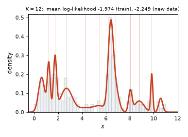

[figure not shown]

**200** of the samples for fitting, **4000 new** samples from the same distribution for checking. On the training samples the mean log-likelihood grows with every extra component (to $-1.974$ at $K = 12$); on new data it peaks at $K = 7$ ($-2.168$) and falls to $-2.249$ at $K = 12$. That is the overfitting from the fifth lecture, only the „model complexity“ is now $K$.

## Expectation–maximization (EM) — formally

*(Just a note, not important for the exam.)*

EM is a general tool in statistics for models with **missing (latent) variables**. Given a model that generates observed data $x$ and missing values $z$, the likelihood for MLE is a marginal:
$$L(\boldsymbol\theta; x) = p(x \mid \boldsymbol\theta)
= \int p(x, z \mid \boldsymbol\theta)\, dz
= \int p(x \mid z, \boldsymbol\theta)\, p(z \mid \boldsymbol\theta)\, dz$$
This integral makes direct maximization intractable. The EM algorithm therefore looks for the MLE of the marginal likelihood by iterating two steps:

**Expectation step** — compute the expected log-likelihood of $\boldsymbol\theta$ under the current estimate $\boldsymbol\theta^{t}$ (an expectation over the missing variables):
$$Q(\boldsymbol\theta \mid \boldsymbol\theta^{t}) =
\mathrm{E}_{z \mid x, \boldsymbol\theta^{t}} \big[ \log L(\boldsymbol\theta; x, z) \big]$$

**Maximization step** — find the parameters that maximize this quantity:
$$\boldsymbol\theta^{t+1} = \arg\max_{\boldsymbol\theta}
Q(\boldsymbol\theta \mid \boldsymbol\theta^{t})$$

**Corrected:** the original factorizes the joint as $p(z \mid x, \boldsymbol\theta)\,p(x \mid \boldsymbol\theta)$, which makes the identity circular, and then says that $p(z \mid x, \boldsymbol\theta)$ *cannot be calculated*. That density is exactly what the E-step computes on the next slide but one; intractable is the **maximization of the marginal likelihood**.

## Expectation–maximization (EM) — the four steps

1. Initialize the parameters $\boldsymbol\theta$.
2. **Expectation (E) step** — compute the probability of each possible value of $z$, given the current estimate of $\boldsymbol\theta$.
3. **Maximization (M) step** — use the estimate of $z$ for a better estimate of $\boldsymbol\theta$.
4. Iterate between the E and the M step.

## What the two steps do — step by step

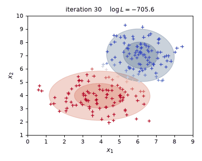

The animation starts from the **converged state**, then replays the iterations from the initialization $\boldsymbol\mu_1 = \mathbf{x}_1$, $\boldsymbol\mu_2 = \mathbf{x}_2$, $\Sigma_k = I$, $w_k = 0.5$.

- **E step** — the colour of every point changes: it is the probability that the point belongs to component 1.
- **M step** — the ellipses move and change shape: each Gaussian is re-estimated from *all* points, weighted by that probability.

Log-likelihood at the start $-999.5$, after convergence $-705.6$.

## EM for GMM — the E step

**E step** — evaluate the likelihood of every point $\mathbf{x}_i$ under every Gaussian $k$ and normalize, to get the probability that this point comes from component $k$ (its **responsibility**):

$$q(\mathbf{x}_i; \boldsymbol\theta_k) =
\frac{w_k\, p(\mathbf{x}_i; \boldsymbol\theta_k)}
{\sum_{j=1}^{K} w_j\, p(\mathbf{x}_i; \boldsymbol\theta_j)},
\qquad
\boldsymbol\theta_k = [\boldsymbol\mu_k, \Sigma_k]$$

$$p(\mathbf{x}_i; \boldsymbol\theta_k) = (2\pi)^{-\frac{d}{2}}\, |\Sigma_k|^{-\frac{1}{2}}
\exp\!\left( -\tfrac{1}{2}(\mathbf{x}_i - \boldsymbol\mu_k)^{T}\Sigma_k^{-1}
(\mathbf{x}_i - \boldsymbol\mu_k) \right)$$

By construction $\sum_{k=1}^{K} q(\mathbf{x}_i; \boldsymbol\theta_k) = 1$ for every point — it is a distribution over components, one per sample.

This is **Bayes’ rule again**: prior $w_k$, likelihood $p(\mathbf{x}_i; \boldsymbol\theta_k)$, posterior $q$ — the same structure as the class posterior in the naive Bayes block, only the „class“ is now hidden.

## EM for GMM — the M step

**M step** — take the MLE estimate for each Gaussian, with every point weighted by the probability that it belongs to component $k$:

$$w_k = \frac{1}{n}\sum_{i=1}^{n} q(\mathbf{x}_i; \boldsymbol\theta_k),
\qquad
\boldsymbol\mu_k = \frac{\sum_{i=1}^{n} q(\mathbf{x}_i; \boldsymbol\theta_k)\, \mathbf{x}_i}
{\sum_{i=1}^{n} q(\mathbf{x}_i; \boldsymbol\theta_k)}$$

$$\Sigma_k = \frac{\sum_{i=1}^{n} q(\mathbf{x}_i; \boldsymbol\theta_k)
(\mathbf{x}_i - \boldsymbol\mu_k)(\mathbf{x}_i - \boldsymbol\mu_k)^{T}}
{\sum_{i=1}^{n} q(\mathbf{x}_i; \boldsymbol\theta_k)}$$

These are the **same MLE formulas** as for a single Gaussian, with the counts replaced by sums of responsibilities. If all $q$ were 0 or 1, they would reduce to „split the points by label and fit each part separately“.

[`kod/em_gmm.py`](https://github.com/tomasvicar/MLR/blob/master/lectures_latex_2025/L12/kod/em_gmm.py) — both steps in about 30 lines of numpy, checked against `sklearn.mixture.GaussianMixture`.

## GMM estimation by EM — the algorithm

Algorithm for two 2D Gaussians ($d = 2$, $K = 2$):

1. Initialization of $\boldsymbol\mu_1, \boldsymbol\mu_2, \Sigma_1, \Sigma_2, w_1, w_2$.
2. Compute the normalized likelihoods $q(\mathbf{x}_i; \boldsymbol\theta_1)$ and $q(\mathbf{x}_i; \boldsymbol\theta_2)$ for all points (**E step**).
3. Compute $w_1$ and $w_2$ as the mean of $q(\mathbf{x}_i; \boldsymbol\theta_k)$ over all points, and re-estimate $\boldsymbol\mu_1, \boldsymbol\mu_2, \Sigma_1, \Sigma_2$ (**M step**).
4. Repeat steps 2–3 **until** a stopping criterion is met.

**Stopping criterion:**

- maximal number of iterations,
- change of the parameters below a limit, $\|\boldsymbol\mu^{t+1} - \boldsymbol\mu^{t}\| < \epsilon$,
- (in practice also: increase of $\log L$ below a limit).

[figure not shown]

The original says „repeat until stopping criteria **are not** met“ and uses $i$ — the sample index everywhere else — as the iteration index; here it is $t$.

## 3 · Logistic regression

> The promise from the fourth lecture, now with the derivation: where the sigmoid and the log-loss actually come from.

## Logistic regression — what it is

Logistic regression is a method for building a statistical model used in **classification problems**. It lets us take some features and predict the correct class — or better, the **probability of that class**.

We met it already in the fourth lecture, as a linear classifier with a sigmoid and a log-loss. Today we derive it: the sigmoid and the loss both fall out of a **Bernoulli likelihood plus MLE**.

Despite the name, it is a **classification** method. It is *discriminative* — it models $p(y \mid \mathbf{x})$ directly and never models $p(\mathbf{x})$, unlike the naive Bayes classifier from the first block.

## Linear versus logistic regression

- We can predict **whether** a student passes the exam (yes / no) based on the number of hours spent studying. That is a task for **logistic regression**.
- We can predict **how many points** the student gets („almost“ a continuous variable) based on the number of hours spent studying. That is a task for **linear regression**.

[figure not shown]

The same input, two different outputs — and therefore two different models. The sigmoid on the left cannot leave $[0, 1]$; the line on the right can predict any number. The 500 students are the seminar data set; the exam score on the right is **added** for this comparison, because the file records only pass/fail.

## Definition

We want to predict the probability that we classify a **cat** (i.e. $y_i = 1$), given the input (a feature vector $\mathbf{x}_i$) and the parameters of the model $\mathbf{w}$:
$$p(y_i = 1 \mid \mathbf{x}_i, \mathbf{w}) = \ ?$$

It does not make sense to use a **linear** model, because it would just fit a line through our data. But we can use some function to transform the linear model into something more convenient.

[figure not shown]

## Sigmoid function

For this purpose we use the **sigmoid** function:
$$\sigma(z) = \frac{1}{1 + e^{-z}}$$

Its useful properties:

- whatever the input is, it is transformed into $(0, 1)$,
- the derivative with respect to the input is very convenient:

$$\frac{d\,\sigma(z)}{dz} = \sigma(z)\,\big(1 - \sigma(z)\big)$$

[figure not shown]

The derivative never exceeds $0.25$ (for the plain sigmoid used here; the sixth lecture writes it with a temperature $T$, where the maximum is $1/(4T)$) — hence the vanishing-gradient problem.

## Logistic regression — the Bernoulli model

We use the sigmoid to transform the linear model:
$$\theta = \sigma(\mathbf{w}^{T}\mathbf{x}) = \frac{1}{1 + e^{-\mathbf{w}^{T}\mathbf{x}}}$$

**Bernoulli probability distribution** (from the previous lecture):
$$f(y \mid \theta) = \theta^{y}\,(1 - \theta)^{1 - y}, \qquad y \in \{0, 1\}$$

We can now look at our data in a different way: the **labels are Bernoulli random variables**, and the model given by the sigmoid supplies their parameter $\theta$ — a different one for every sample.

Notation: here $\mathbf{w}^{T}\mathbf{x}$ has the **bias absorbed into the weights** — $x_0 = 1$ and $w_0 = b$. The fourth lecture writes the same model as $\mathbf{w}^{T}\mathbf{x} + b$; the two are identical.

## Logistic regression — the likelihood

The likelihood is the „probability“ that the observed labels come from a specific model (Bernoulli) with parameters $\mathbf{w}$. For **independent and identically distributed** samples it is a product:

$$\mathcal{L}(\mathbf{w} \mid \mathbf{y}, \mathbf{x}_1, \dots, \mathbf{x}_n)
= \prod_{i=1}^{n}
\sigma(\mathbf{w}^{T}\mathbf{x}_i)^{\,y_i}
\big(1 - \sigma(\mathbf{w}^{T}\mathbf{x}_i)\big)^{\,1 - y_i}$$

For a sample with $y_i = 1$ only the first factor survives, for $y_i = 0$ only the second — the exponents work as a switch.

The original writes $\prod_i^{n}$ without the lower limit, and describes the likelihood as the probability of the data $x$; formally it is the likelihood of the **labels** $\mathbf{y}$ given the inputs — which the formula itself has right.

## Solution — the log-likelihood is the negative cross-entropy

Maximizing a product is numerically bad. Better to maximize the **log** of the likelihood:
$$\mathcal{L}_{\text{log}} = \log \mathcal{L}(\mathbf{w} \mid \mathbf{y},
\mathbf{x}_1, \dots, \mathbf{x}_n)
= \sum_{i=1}^{n} y_i \log\big(\sigma(\mathbf{w}^{T}\mathbf{x}_i)\big)
+ (1 - y_i) \log\big(1 - \sigma(\mathbf{w}^{T}\mathbf{x}_i)\big)$$

With $\hat y_i = \sigma(\mathbf{w}^{T}\mathbf{x}_i)$ this is exactly the **binary cross-entropy of the fourth lecture** (the two-class case of the weighted cross-entropy of the sixth), with the opposite sign and averaged over the $n$ samples:
$$\mathrm{BCE} = -\frac{1}{n}\sum_{i=1}^{n}
\big[\, y_i \log \hat y_i + (1 - y_i)\log(1 - \hat y_i) \,\big]
= -\frac{1}{n}\,\mathcal{L}_{\text{log}}$$

Maximizing the log-likelihood **is** minimizing the binary cross-entropy. Computed on the student data with $n = 500$:

- $\mathcal{L}_{\text{log}} = -148.78$
- $\mathrm{BCE} = 0.297569$
- $-n \cdot \mathrm{BCE} = -148.78$

**Corrected:** the original says the log-likelihood „is binary cross-entropy“. It is its **negative**; cross-entropy is defined with the minus sign in the sixth lecture and is *minimized*, while the log-likelihood is *maximized*. Careful with the symbol: the fourth lecture writes $\mathcal{L}_{\text{log}}$ for the *log-loss*, i.e. for $-\mathcal{L}_{\text{log}}$ of this slide.

## Solution — the derivative and gradient ascent

We maximize with respect to $\mathbf{w}$, so we take the derivative. Thanks to $\sigma' = \sigma(1-\sigma)$ almost everything cancels:
$$\frac{d\,\mathcal{L}_{\text{log}}(\mathbf{w} \mid \mathbf{y}, \mathbf{x}_1,
\dots, \mathbf{x}_n)}{d\,w^{(j)}}
= \sum_{i=1}^{n} \big(y_i - \sigma(\mathbf{w}^{T}\mathbf{x}_i)\big)\, x_i^{(j)}$$

There is no closed-form solution, so we optimize numerically — **gradient ascent**:
$$w^{(j)}_{\text{new}} = w^{(j)}_{\text{old}} + \mu
\sum_{i=1}^{n} \big(y_i - \sigma(\mathbf{w}^{T}\mathbf{x}_i)\big)\, x_i^{(j)}$$

The gradient is the **error** $y_i - \hat y_i$ times the input — the same form as the weight update derived in the sixth lecture.

The original writes an extra comma right after the conditioning bar, $\mathcal{L}(\mathbf{w}\mid, \mathbf{y}, \dots)$ — twice, in the derivative and in the log-likelihood above it.

## Gradient ascent — step by step

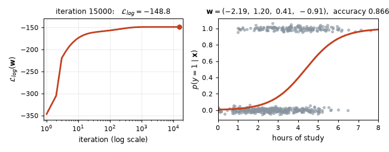

Every frame is one state of $\mathbf{w}$ during the update above, starting from $\mathbf{w} = \mathbf{0}$ — where the model says $p = 0.5$ for everybody and $\mathcal{L}_{\text{log}} = n \log \tfrac12 = -346.6$. The first few hundred iterations do almost all the work; the remaining thousands only sharpen the curve.

## Logistic regression — trained

[figure not shown]

500 students, three features (hours of study, practice tests, beers the day before), trained by the gradient ascent formula above with $\mu = 0.0005$.

|  | $w_0$ | hours | tests | beers |
| --- | --- | --- | --- | --- |
| gradient ascent | $-2.191$ | $1.197$ | $0.411$ | $-0.910$ |
| generating model | $-2.0$ | $1.2$ | $0.4$ | $-0.9$ |

Accuracy on those same 500 students $0.866$; the largest difference from `sklearn.linear_model.LogisticRegression` without regularization is $0.0003$. [`kod/logisticka_regrese.py`](https://github.com/tomasvicar/MLR/blob/master/lectures_latex_2025/L12/kod/logisticka_regrese.py)

## Interpretation — odds and log-odds

**Odds** $= \dfrac{p}{1-p}$ — e.g. $\dfrac{0.2}{0.8} = 0.25$ for a probability of 20 %.

**Log-odds** are what the linear part of the model predicts:
$$\log \frac{p}{1-p} = \mathbf{w}^{T}\mathbf{x}$$

A single weight $w_j$ is therefore read like a weight in linear regression:

- large positive → increasing this feature leads to a larger probability,
- large negative → increasing this feature leads to a smaller probability,
- close to 0 → an unimportant feature.

[figure not shown]

## Interpretation — the odds ratio

**Odds ratio** — $e$ to the power of the weight, $OR_j = e^{w_j}$. If the corresponding feature increases by 1, the **odds are multiplied** by the odds ratio.

| $OR_j$ | starting $p$ | starting odds | new odds | **new $p$** |
| --- | --- | --- | --- | --- |
| $1.42$ (increase by 42 %) | 10 % | $0.1111$ | $0.1578$ | **13.6 %** |
| $0.42$ (decrease to 42 %) | 10 % | $0.1111$ | $0.0467$ | **4.5 %** |

From the trained model of the previous slide:

| feature | $w_j$ | $OR_j$ | 10 % becomes |
| --- | --- | --- | --- |
| hours of study | $1.197$ | $3.309$ | 26.9 % |
| practice tests | $0.411$ | $1.509$ | 14.4 % |
| beers | $-0.910$ | $0.402$ | 4.3 % |

The original stops at the new odds; the last column (the new probability) is computed here, because that is the number a reader understands.

## Summary — three models, one recipe

|  | naive Bayes | Gaussian mixture | logistic regression |
| --- | --- | --- | --- |
| **task** | classification | clustering / density | classification |
| **type** | generative | generative (no classes) | discriminative |
| **models** | $p(\mathbf{x} \mid y_k)\, p(y_k)$ | $p(\mathbf{x})$ | $p(y \mid \mathbf{x})$ |
| **labels needed** | yes | **no** | yes |
| **assumption** | features independent given the class | data are a mixture of $K$ Gaussians | log-odds are linear in $\mathbf{x}$ |
| **estimation** | MLE / MAP, closed form | EM, iterative | gradient ascent on $\mathcal{L}_{\text{log}}$ |
| **output** | posterior over $K$ classes | responsibilities $q$ | probability of class 1 |

Every one of them is the same recipe: **write down the likelihood, then maximize it.**

## Summary — where the loss functions came from

| assumption about the data | maximum likelihood gives | known from |
| --- | --- | --- |
| Gaussian noise $\varepsilon \sim \mathcal{N}(0, \sigma^2)$ | L2 loss $\sum_i (y_i - \hat y_i)^2$ | sixth lecture |
| Bernoulli labels $y \sim \mathrm{Bern}(\sigma(\mathbf{w}^{T}\mathbf{x}))$ | binary cross-entropy | fourth and sixth lecture |
| Gaussian prior on the weights | L2 regularization / weight decay | sixth lecture |
| a mixture of $K$ Gaussians | the EM algorithm | today |

Loss functions are not arbitrary. Each of them is $-\log$ of a probabilistic assumption — which is why probability theory is the language in which new models are invented.

## 4 · Recap

> Three sets of questions: the Bayes classifier, the mixture model, and logistic regression.

## Recap quiz I — probability and naive Bayes

- Write **Bayes’ rule for a class posterior** and name all four terms. Which one can be dropped when we only want the most probable class, and why?
- Derive the **L2 loss** from maximum likelihood. Which assumption about the noise did you use, and what would change for Laplace noise?
- State the **naive assumption**. Is it independence of the features, or something weaker?
- How many distributions does a naive Bayes classifier fit for $K$ classes and $d$ features? How many parameters does one full $d$-dimensional Gaussian need?
- Naive Bayes is called *robust to missing features*. Explain why, using the product formula.
- The naive assumption is almost always violated. Why does the classifier still work?

## Recap quiz II — Gaussian mixture model and EM

- Write the density of a **multivariate Gaussian**. What shape must $\Sigma$ have, and what would go wrong if the off-diagonal entries were $\sigma_i\sigma_j$?
- Write the MLE estimate of $\Sigma$. Which factor carries the transpose, and what is the shape of the result?
- Why **cannot** the closed-form MLE formulas be used for a mixture? What exactly is missing?
- Write the **E step** and say which quantity from the first block it is the same as. For one point, $w_1 p(\mathbf{x}_i; \boldsymbol\theta_1) = 0.03$ and $w_2 p(\mathbf{x}_i; \boldsymbol\theta_2) = 0.01$ — what are the two responsibilities?
- Write the **M step**. How does it differ from fitting a single Gaussian?
- What does the **log-likelihood** do from iteration to iteration, and what follows for the stopping criterion?
- How is a GMM related to **$k$-means** from the first lecture? Name two differences.

## Recap quiz III — logistic regression

- Why does a **linear** model not work for a binary label? What exactly does the sigmoid fix?
- Write $\sigma(z)$ and its derivative. What is the maximum of the derivative, and where did we meet that number before?
- Write the **likelihood** of logistic regression. Where does the Bernoulli distribution enter?
- Show that the log-likelihood is the **negative binary cross-entropy**. Which one do we maximize and which one do we minimize?
- Write the gradient ascent update. Why is there a plus and not a minus?
- A weight is $w_j = 0.7$. What is the odds ratio, and what does a probability of 20 % become if that feature increases by 1?
- Which of today’s three models is **discriminative** and which are **generative**? What can a generative model do that a discriminative one cannot?